# バブル・マップを用いた地価の可視化

神奈川県の例

[岩田真一郎](https://shinichiro-iwata.github.io/)（[神奈川大学経済学部](https://www.econ.kanagawa-u.ac.jp/)）

2022-06-06

# 目的

地価公示（ポイント）の大きさを変えることにより，地価が高い箇所を強調表現（地価が低い箇所は抑制表現）．ポイントはバブル（泡）と言い換えられ，バブルを使った図はバブル・チャートとよばれる．地図の場合はバブル・マップとよぶ．

ライブラリ：`sf`，`tidyverse`

```r
library(sf)
library(tidyverse)
```

# 地価公示の可視化

[4](https://shinichiro-iwata.github.io/GIS-data-visualization/point-data-visualization.html)で作成した神奈川県の地価（2022年）を再現．

**シェープファイルのダウンロード**

- [国土数値情報ダウンロードサービス](https://nlftp.mlit.go.jp/ksj/) > 行政区域（ポリゴン） > 神奈川県 > 令和3年
- [国土数値情報ダウンロードサービス](https://nlftp.mlit.go.jp/ksj/) > 地価公示（ポイント） > 神奈川県 > 「神奈川県」データのダウンロード > 世界測地系 令和4年
  - ダウンロードしたZIPファイルは同じディレクトリに納め，ZIPファイルを選択 > 右クリック > 解凍 > ここで解凍 を実行する．解凍後は最初にダウンロードしたZIPファイルを削除．
  - シェープファイルの読み込み（`read_sf`）：行政区域を`Kanagawa_map`，地価公示を`Kanagawa_lp`と名付ける．

```r
Kanagawa_map<-read_sf('N03-20210101_14_GML/N03-21_14_210101.shp')

Kanagawa_lp<-read_sf('L01-22_14_GML/L01-22_14.shp')
```

**データのソート**

地価（`L01_006`）が高いポイントの色が上にくるよう順番を変更（`arrange`）．

- データ名は`Kanagawa_lp`のまま．

```r
Kanagawa_lp %>%
  arrange(L01_006) ->
  Kanagawa_lp
```

**再現図形**

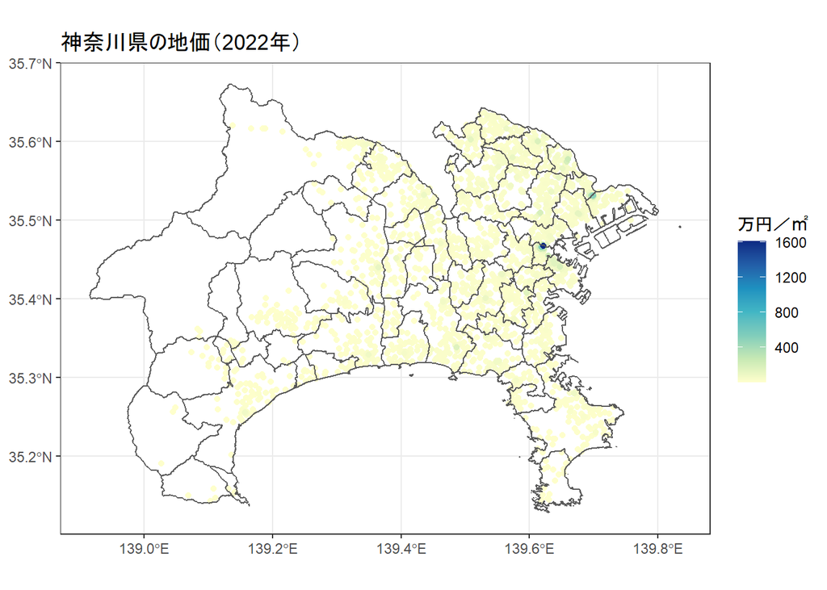

# バブル・マップを用いた可視化

地価公示ポイント（バブル）の大きさを変えるために，`aes(size)`を利用する．これを活かすために，地価公示ポイント（`x`軸が経度，`y`軸が緯度）の変数を作成．

- 地価公示ポイントは緯度経度により表現される．この情報は列名`geometry`にすでに納められている．
  - `データ名[c("列名")]`：列の中身を確認．

```r
Kanagawa_lp[c("geometry")]
```

```
## Simple feature collection with 1787 features and 0 fields
## Geometry type: POINT
## Dimension:     XY
## Bounding box:  xmin: 139.0266 ymin: 35.14204 xmax: 139.7578 ymax: 35.63712
## Geodetic CRS:  JGD2000
## # A tibble: 1,787 x 1
##                geometry
##    <POINT [arc_degree]>
##  1  (139.6507 35.20473)
##  2  (139.2251 35.41038)
##  3  (139.1146 35.25959)
##  4  (139.3062 35.46262)
##  5    (139.247 35.3452)
##  6  (139.4259 35.40653)
##  7  (139.5964 35.36467)
##  8  (139.5203 35.49649)
##  9  (139.0488 35.26175)
## 10  (139.0972 35.33835)
## # ... with 1,777 more rows
```

```r
mutate(Kanagawa_lp,
       x=st_coordinates(geometry)[, 1],
       y=st_coordinates(geometry)[, 2]) ->
  Kanagawa_lp

#列の中身を確認
Kanagawa_lp[c("geometry", "x", "y")]
```

```
## Simple feature collection with 1787 features and 2 fields
## Geometry type: POINT
## Dimension:     XY
## Bounding box:  xmin: 139.0266 ymin: 35.14204 xmax: 139.7578 ymax: 35.63712
## Geodetic CRS:  JGD2000
## # A tibble: 1,787 x 3
##                geometry     x     y
##    <POINT [arc_degree]> <dbl> <dbl>
##  1  (139.6507 35.20473)  140.  35.2
##  2  (139.2251 35.41038)  139.  35.4
##  3  (139.1146 35.25959)  139.  35.3
##  4  (139.3062 35.46262)  139.  35.5
##  5    (139.247 35.3452)  139.  35.3
##  6  (139.4259 35.40653)  139.  35.4
##  7  (139.5964 35.36467)  140.  35.4
##  8  (139.5203 35.49649)  140.  35.5
##  9  (139.0488 35.26175)  139.  35.3
## 10  (139.0972 35.33835)  139.  35.3
## # ... with 1,777 more rows
```

**バブル・マップを用いた可視化**

- `aes(x=x, y=y)`：`x`軸を↑で作成した`x`の値を，`y`軸を↑で作成した`y`の値を使うように指示．これにより，泡（地価ポイント）の位置（緯度経度）が確定する．
- `aes(color=, size=)`で泡（地価ポイント）の色（`color`）と大きさ（`size`）を指示．
  - `aes(size=L01_006/10000)`：泡（地価ポイント）の大きさを2022年の地価（`L01_006`）の高低で表現できるようにに指示．
  - ここでは単位を万円／㎡にするために`L01_006`を1万（`10000`）で割る．
- `guide="legend"`：凡例を制御．指示しない場合，`color`と`size`の凡例が別々に表現される．
- `scale_size_area(max_size=10)`で泡の大きさの最大値を指示．
- `x=""`，`y=""`を記すことで，`x`軸と`y`軸のラベル削除．

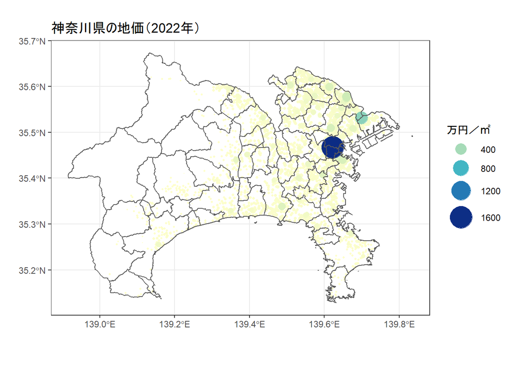

```r
ggplot()+
  geom_sf(data=Kanagawa_map, fill="white")+
  geom_point(data=Kanagawa_lp,
             aes(x=x, y=y,
              color=L01_006/10000,
              size=L01_006/10000))+
  scale_color_distiller(palette="YlGnBu", direction=1,
                        guide="legend")+
  scale_size_area(max_size=10)+
  geom_sf(data=Kanagawa_map, fill="NA")+
  labs(color="万円／㎡", size="万円／㎡",
       x="", y="")+
  ggtitle("神奈川県の地価（2022年）")+
  theme_bw()
```

凡例のデータの分類の間隔（閾値）を自分で作成し，`my_breaks`と名付ける．

- `scale_color_distiller()`，`scale_size_area()`ともにデータの分類間隔(`breaks`)に`my_breaks`を適用するように指示．

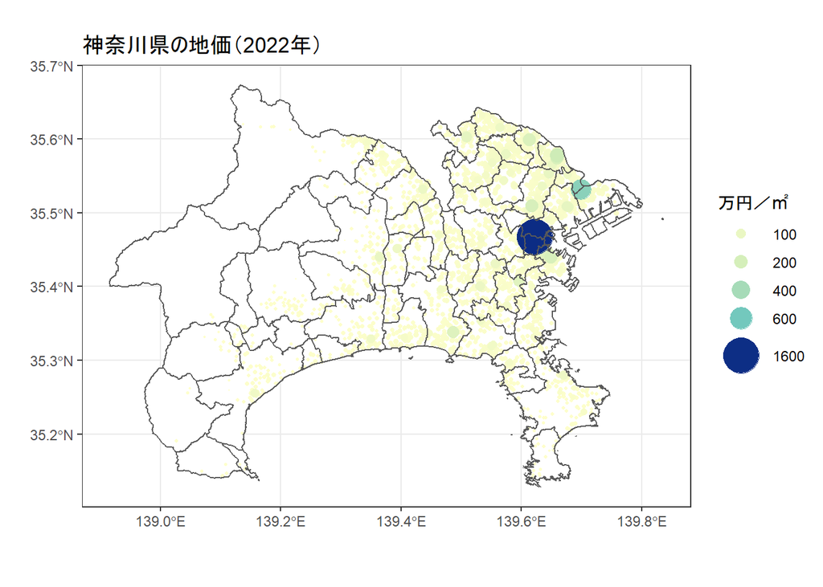

```r
my_breaks<-c(100, 200, 400, 600, 1600)

ggplot()+
  geom_sf(data=Kanagawa_map, fill="white")+
  geom_point(data=Kanagawa_lp,
             aes(x=x, y=y,
                 color=L01_006/10000, size=L01_006/10000))+
  scale_color_distiller(palette="YlGnBu", direction=1,
                        guide="legend", breaks=my_breaks)+
  scale_size_area(max_size=10, breaks=my_breaks)+
  geom_sf(data=Kanagawa_map, fill="NA")+
  labs(color="万円／㎡", size="万円／㎡",
       x="", y="")+
  ggtitle("神奈川県の地価（2022年）")+
  theme_bw()
```

**参考ウェブサイト**

- [Bubble map with ggplot2](https://r-graph-gallery.com/330-bubble-map-with-ggplot2.html) – [the R Graph Gallery](https://r-graph-gallery.com/)

**Rによる地理空間データの可視化**

- チュートリアル[ホーム](https://shinichiro-iwata.github.io/GIS-data-visualization/)